# Case Study Two

Julius Horvath, Michael Barker, Adam Scheerer

December 4, 2018

## Question 1

We will delete the Question 1 title above. Here are the questions we need to knock out. Remember this is not supposed to look like a student project so we will delete many of these things as they are completed.

1. The client wants this to be reproducible and know exactly what you did. There needs to be an informative Readme, complete with several sections, as referenced in Live Session. Give contact information, session Info, and the objective of the repo at least.
2. Create a file structure that is accessible and transparent. Document it in the root directory, ideally in the Readme.

[session information not shown]

```r
data<-read.csv(file="CaseStudy2data.csv", header=TRUE)
print('The number of rows and columns in the data set are:')
```

```
## [1] "The number of rows and columns in the data set are:"
```

```r
nrow(data)
```

```
## [1] 1470
```

```r
ncol(data)
```

```
## [1] 35
```

## Cleaning the Data

```r
data<-read.csv(file="CaseStudy2data.csv", header=TRUE)
names(data)
```

```
##  [1] "Age"             "Attrition"       "BusTravel"
##  [4] "DailyRate"       "Department"      "HomeDist"
##  [7] "Education"       "EducField"       "EmployeeCnt"
## [10] "EmployeeNum"     "EnviroSat"       "Gender"
## [13] "HourlyRate"      "JobInvolv"       "JobLevel"
## [16] "JobRole"         "JobSat"          "MaritalStat"
## [19] "MthlyInc"        "MonthlyRate"     "NumCompWrk"
## [22] "Over18"          "OverTime"        "PercSalInc"
## [25] "PerfRating"      "RelationshipSat" "StndHrs"
## [28] "StkOptLevel"     "TotWrkYrs"       "TrnTmsLstYr"
## [31] "WrkLifeBal"      "YrsAtComp"       "YrsCurrRole"
## [34] "YrsLstProm"      "YrsCurrMgr"
```

```r
newnames<-read.csv("NewParameterNames.csv")
names(data)<-newnames$NewTerm
data$EmployeeCnt<- NULL#Here we are getting rid of columns that all have the same value
data$EmployeeNum<-NULL
data$StndHrs<-NULL
data$Over18<-NULL
data$Attrition<-as.character(data$Attrition)
data$Attrition[data$Attrition=='Yes']<-1 #We are recoding Attrition; Yes as 1 and No as 0 so that regression equations will run
data$Attrition[data$Attrition=='No']<-0
data$JobRole<-as.character(data$JobRole)
data$JobRole[data$JobRole=='Human Resources']<-'HumanResources'#Here we are eliminating spaces so that we can put this in graphs
data$JobRole[data$JobRole=='Laboratory Technician']<- 'LabTech'
data$JobRole[data$JobRole=='Manager']<-'Manager'
data$JobRole[data$JobRole=='Manufacturing Director']<-'ManufacturingDirector'
data$JobRole[data$JobRole=='Research Director']<- 'ResearchDirector'
data$JobRole[data$JobRole=='Research Scientist ']<- 'ResearchScientist'
data$JobRole[data$JobRole=='Sales Executive']<-'SalesExecutive'
data$JobRole[data$JobRole=='Sales Representative']<- 'SalesRep'
data$OverTime<-as.character(data$OverTime)
data$OverTime[data$OverTime=='Yes']<-1 #Recoding Overtime Yes and No to 1 and 0 respectively
data$OverTime[data$OverTime=='No']<-0
data$MaritalStat <- as.character(data$MaritalStat)
data$MaritalStat[data$MaritalStat=='Married']<-1#Recoding Single, Married, and Divorced to 0,1,2 respectively to put in equations.
data$MaritalStat[data$MaritalStat=='Single']<-0
data$MaritalStat[data$MaritalStat=='Divorced']<-2
data$Attrition<-as.integer(data$Attrition)
```

```r
sapply(data, class) #this shows what class they are
```

```
##         Age   Attrition   BusTravel   DailyRate  Department    HomeDist
##   "integer"   "integer"    "factor"   "integer"    "factor"   "integer"
##   Education   EducField   EnviroSat      Gender  HourlyRate   JobInvolv
##   "integer"    "factor"   "integer"    "factor"   "integer"   "integer"
##    JobLevel     JobRole      JobSat MaritalStat    MthlyInc MonthlyRate
##   "integer" "character"   "integer" "character"   "integer"   "integer"
##  NumCompWrk    OverTime  PercSalInc  PerfRating RelationSat StkOptLevel
##   "integer" "character"   "integer"   "integer"   "integer"   "integer"
##   TotWrkYrs TrnTmsLstYr  WrkLifeBal   YrsAtComp YrsCurrRole  YrsLstProm
##   "integer"   "integer"   "integer"   "integer"   "integer"   "integer"
##  YrsCurrMgr
##   "integer"
```

## Checking to make sure the ages of our datapoints are appropriate…

```r
min(data$Age) #checking to see if any under 18. Since there are not, no need to remove at this point.
```

```
## [1] 18
```

#### The data is appropriate to use, now we can begin our Exploratory Data Analysis

#### We have many histograms here for you to look at

```r
data$LifeSat <- data$JobSat
data$LifeSat<- data$LifeSat +data$EnviroSat
data$LifeSat <- data$LifeSat+data$RelationSat
summary(data$JobSat)   #lets make these histograms look better and supply commentary on them.
```

```
##    Min. 1st Qu.  Median    Mean 3rd Qu.    Max.
##   1.000   2.000   3.000   2.729   4.000   4.000
```

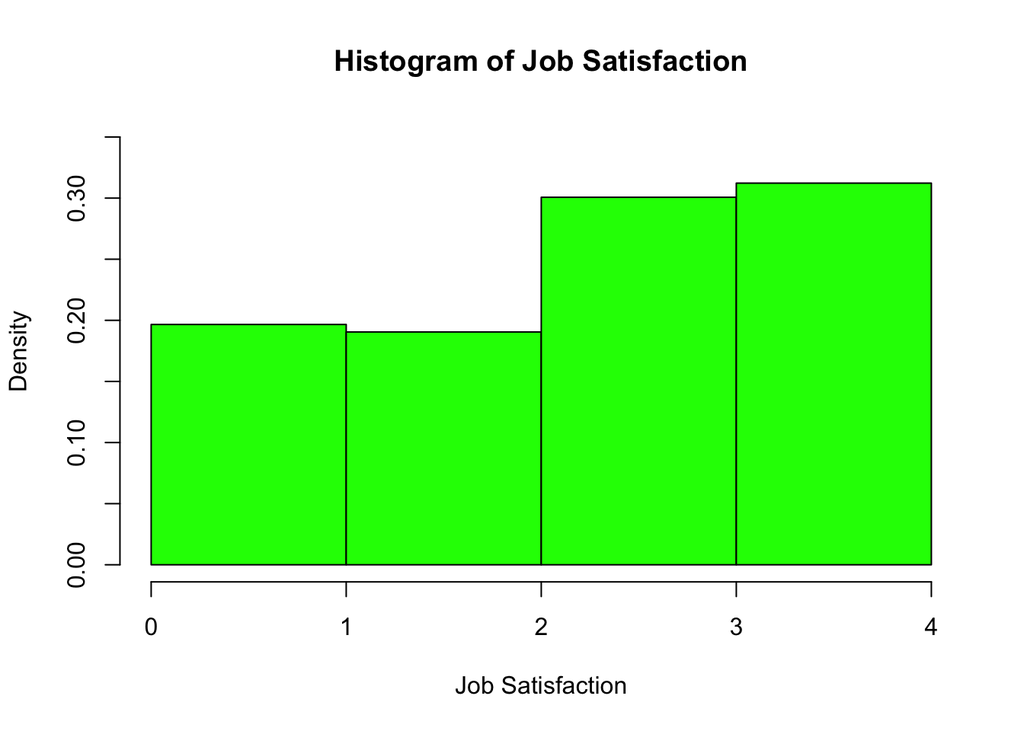

```r
hist(data$JobSat,main='Histogram of Job Satisfaction',xlab='Job Satisfaction',col='green',breaks=c(0,1,2,3,4),prob=T,ylim=c(0,0.35))
```

```r
summary(data$YrsAtComp)   #How many years the employee was at the company.
```

```
##    Min. 1st Qu.  Median    Mean 3rd Qu.    Max.
##   0.000   3.000   5.000   7.008   9.000  40.000
```

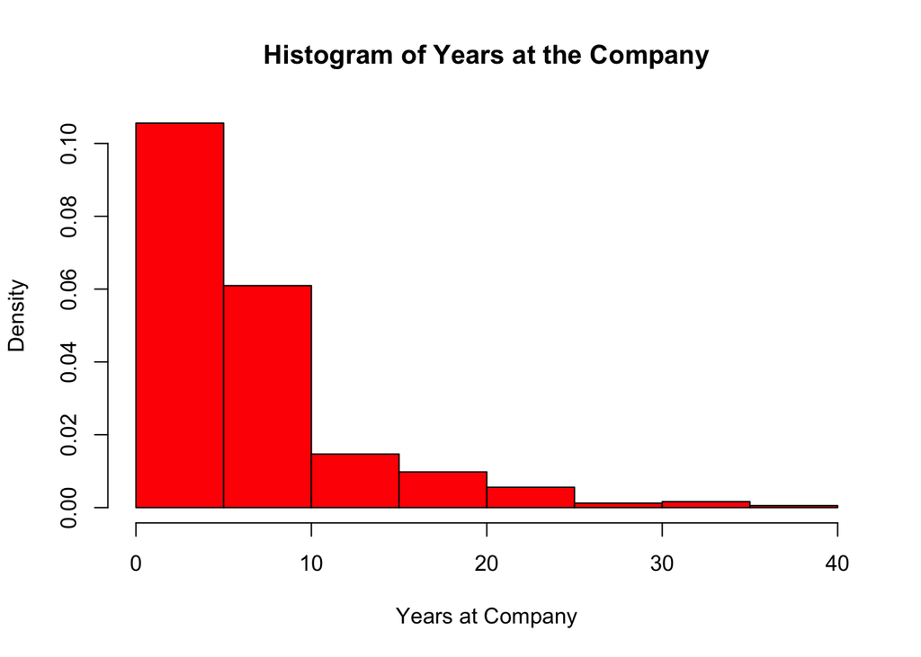

```r
hist(data$YrsAtComp,main='Histogram of Years at the Company',xlab='Years at Company',col='red',xlim=c(0,40),prob=T)
```

```r
summary(data$Education)   #Education level of the employee. Each number indicates how many years of college they have completed.
```

```
##    Min. 1st Qu.  Median    Mean 3rd Qu.    Max.
##   1.000   2.000   3.000   2.913   4.000   5.000
```

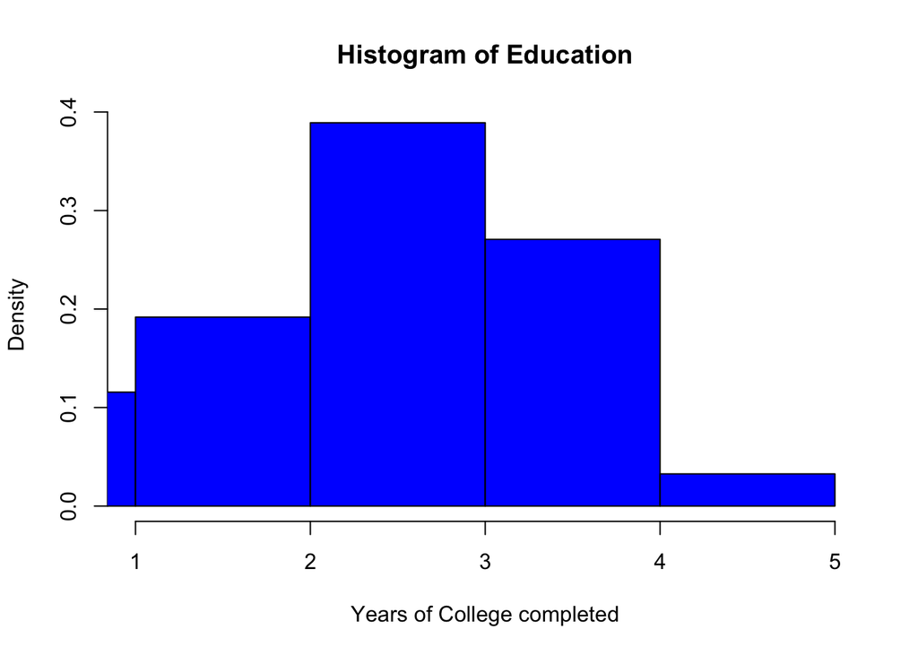

```r
hist(data$Education,main='Histogram of Education',xlab='Years of College completed',col='blue',xlim=c(1,5),breaks=c(0,1,2,3,4,5),prob=T)
```

```r
summary(data$JobLevel)
```

```
##    Min. 1st Qu.  Median    Mean 3rd Qu.    Max.
##   1.000   1.000   2.000   2.064   3.000   5.000
```

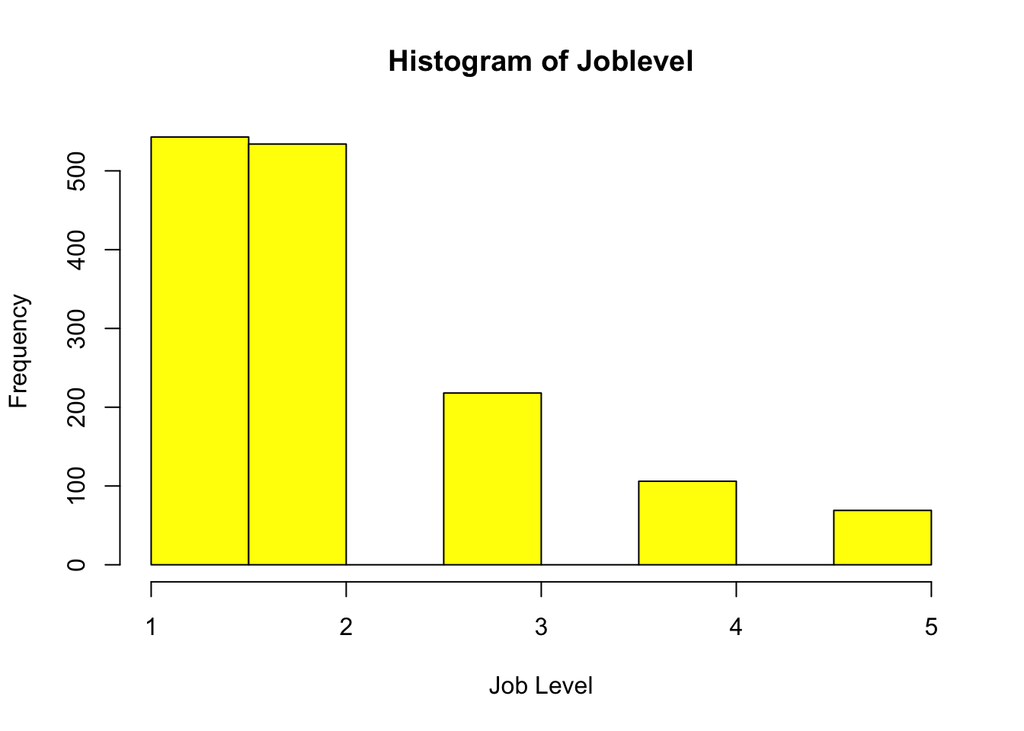

```r
hist(data$JobLevel,main='Histogram of Joblevel',xlab='Job Level', col='yellow',xlim=c(1,5))
```

```r
summary(data$HourlyRate)   #The hourly rate of pay for the employee
```

```
##    Min. 1st Qu.  Median    Mean 3rd Qu.    Max.
##   30.00   48.00   66.00   65.89   83.75  100.00
```

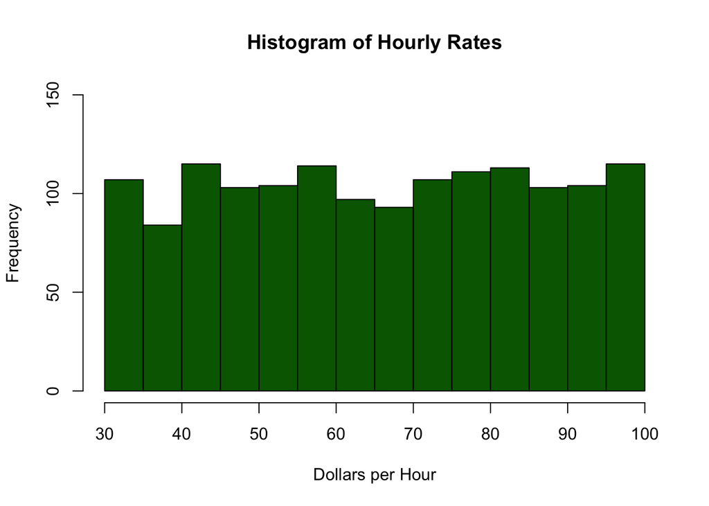

```r
hist(data$HourlyRate,main='Histogram of Hourly Rates',xlab='Dollars per Hour',col='DarkGreen',ylim=c(0,150))
```

```r
summary(data$MonthlyRate)   #The monthly rate of pay (to display monthly income in comparison to hourly pay to show if the employee is less than or more than full time if hourly)
```

```
##    Min. 1st Qu.  Median    Mean 3rd Qu.    Max.
##    2094    8047   14236   14313   20462   26999
```

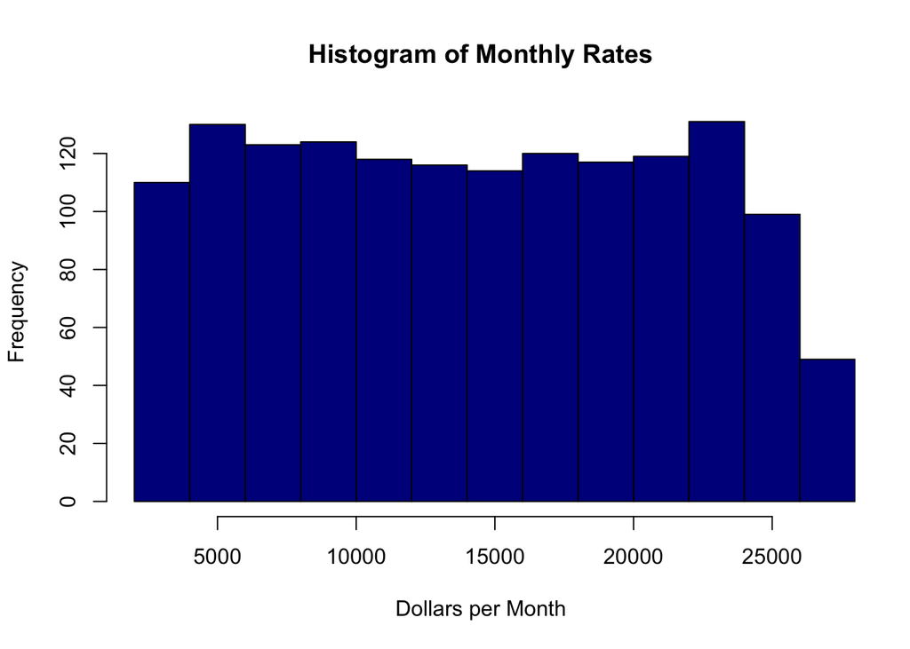

```r
hist(data$MonthlyRate,main='Histogram of Monthly Rates',xlab='Dollars per Month', col='DarkBlue',xlim=c(2000,27000))
```

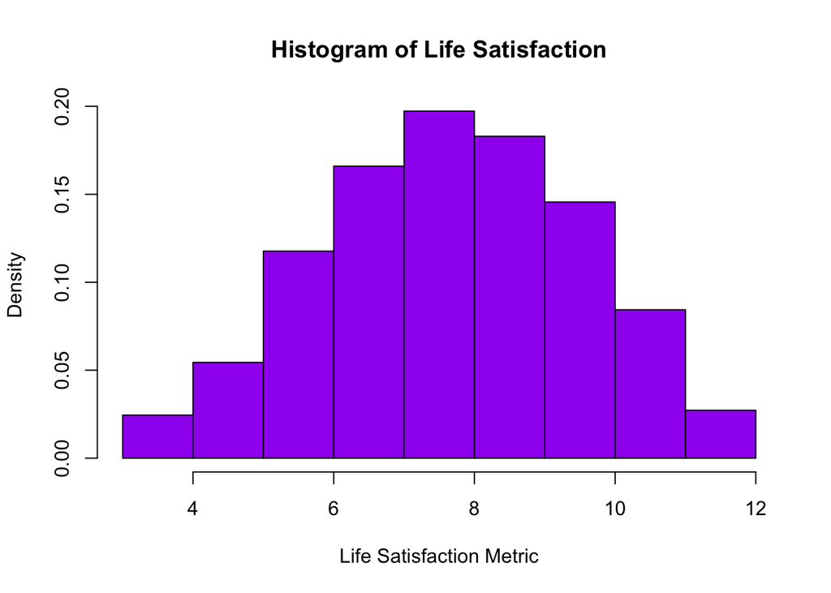

```r
data$LifeSat <- data$JobSat
data$LifeSat<- data$LifeSat +data$EnviroSat
data$LifeSat <- data$LifeSat+data$RelationSat
hist(data$LifeSat,main='Histogram of Life Satisfaction',xlab='Life Satisfaction Metric', col='Purple',xlim=c(3,12),probability = T)
```

```r
summary(data$LifeSat)  #Here is the Histogram of the metric we created for Life Satisfaction.  The Life Satisfaction score is simply the sum of Job Satisfaction, Environment Satisfaction, and Relationsip Satisfaction
```

```
##    Min. 1st Qu.  Median    Mean 3rd Qu.    Max.
##   3.000   7.000   8.000   8.163  10.000  12.000
```

## Counts of relevant categories of data

```r
summary(data$Gender)
```

```
## Female   Male
##    588    882
```

```r
table(data$Gender) #Counts of each gender.
```

```
##
## Female   Male
##    588    882
```

```r
summary(data$Education)
```

```
##    Min. 1st Qu.  Median    Mean 3rd Qu.    Max.
##   1.000   2.000   3.000   2.913   4.000   5.000
```

```r
table(data$Education)#Counts of Education Level
```

```
##
##   1   2   3   4   5
## 170 282 572 398  48
```

```r
summary(data$JobRole)
```

```
##    Length     Class      Mode
##      1470 character character
```

```r
table(data$JobRole) #counts of each job role
```

```
##
## Healthcare Representative            HumanResources
##                       131                        52
##                   LabTech                   Manager
##                       259                       102
##     ManufacturingDirector        Research Scientist
##                       145                       292
##          ResearchDirector            SalesExecutive
##                        80                       326
##                  SalesRep
##                        83
```

```r
table(data$JobRole)[4]  #This displays the number of managers in our dataset.
```

```
## Manager
##     102
```

## Here are our barcharts that seperate a few relevant pieces of data by groups such as Job level and Job Role

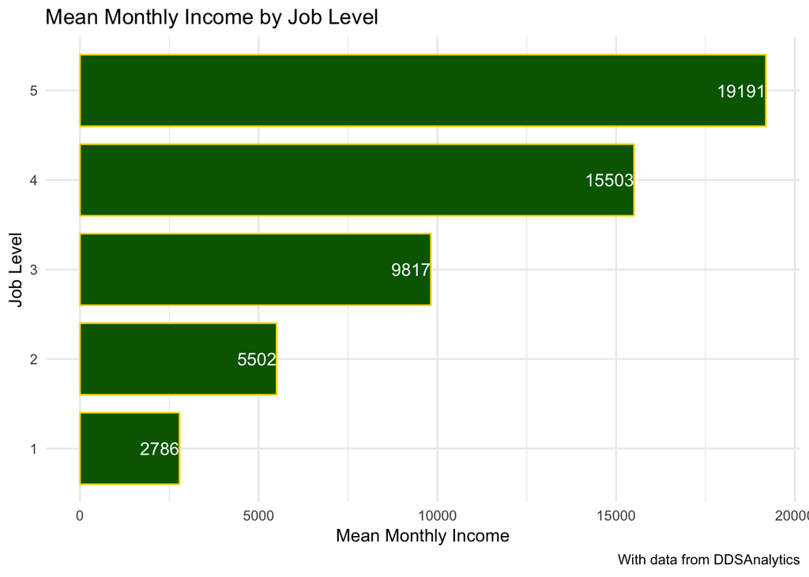

```r
library(ggplot2)
library(plyr)
data.to.plot <-ddply(data,.(JobLevel),summarize,MthlyInc = mean(MthlyInc))
data.to.plot$MthlyInc<- as.integer(data.to.plot$MthlyInc)
data.to.plot$JobLevel<-as.character(data.to.plot$JobLevel)
Income.by.joblevel <- ggplot(data=data.to.plot,aes(x=JobLevel,y=MthlyInc))+
  geom_bar(stat='identity',width=0.8,color='gold',fill='darkgreen')+
  theme_minimal()+
  coord_flip()+
  geom_text(aes(label=MthlyInc),color='white',hjust=1)+
  theme_minimal()+
  labs(title='Mean Monthly Income by Job Level',y='Mean Monthly Income',x='Job Level',caption='With data from DDSAnalytics')
Income.by.joblevel
```

```r
Mean.tot.wrk.yrs.by.joblevel <- ddply(data,.(JobLevel),summarize,TotWrkYrs=mean(TotWrkYrs))
Mean.tot.wrk.yrs.by.joblevel$JobLevel<-as.character(Mean.tot.wrk.yrs.by.joblevel$JobLevel)
Mean.tot.wrk.yrs.by.joblevel$TotWrkYrs<- as.integer(Mean.tot.wrk.yrs.by.joblevel$TotWrkYrs)
Wrk.yrs.joblevel.plot <-ggplot(data=Mean.tot.wrk.yrs.by.joblevel,aes(x=JobLevel,y=TotWrkYrs))+
  geom_bar(stat='identity', width=0.8,color='red',fill='darkblue')+
  theme_minimal()+
  coord_flip()+
  geom_text(aes(label=TotWrkYrs),color='white',hjust=2)+
  theme_minimal()+
  labs(title='Mean Total Work Years by Job Level',y='Mean Total Work Hours',x='Job Level',caption='With data from DDSAnalytics')
summary(Wrk.yrs.joblevel.plot)
```

[output not shown]

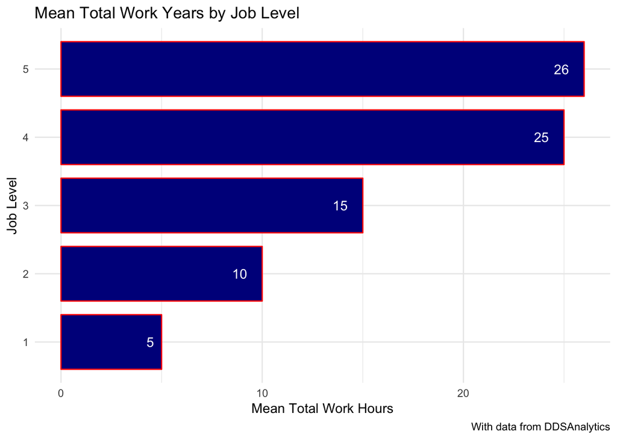

```r
Wrk.yrs.joblevel.plot#This builds on the scatterplot in the next chunk that has log(Monthly Inc) plotted against Age and Years Worked.  The higher the job level correlates with more years worked and in turn high Monthly wages.
```

```r
job.level.5 <- subset(data,JobLevel==5,select=c(JobLevel,Attrition))
count(job.level.5$Attrition,vars=1)#Here we see an Attrition rate of 7% at Job Level 5
```

```
##   x freq
## 1 0   64
## 2 1    5
```

```r
job.level.3 <- subset(data,JobLevel==3,select=c(JobLevel,Attrition))
count(job.level.3$Attrition,vars=1) #Attrition rate rises to 14.7% at Job Level 3
```

```
##   x freq
## 1 0  186
## 2 1   32
```

```r
job.level.1 <- subset(data,JobLevel==1,select=c(JobLevel,Attrition))
count(job.level.1$Attrition,vars=1) #Again the Attrition rate continues to rise and is up to 26.3% at Job Level 1
```

```
##   x freq
## 1 0  400
## 2 1  143
```

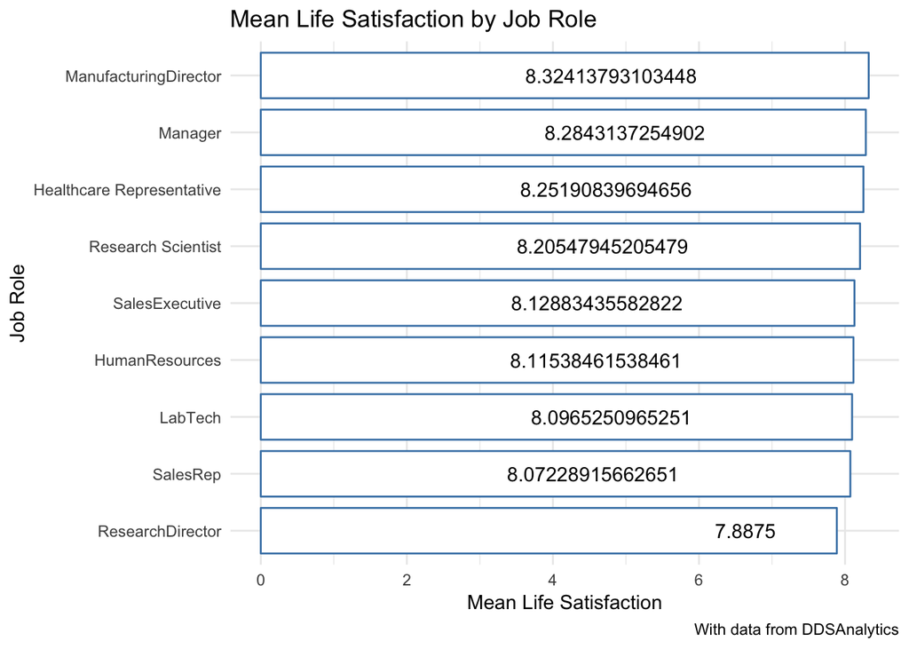

```r
#We see in our final linear regression equation toward the end that each additional Work Year lowers the chance of attrition by 0.008 so all of this seems to add up.

LifeSat.by.JobRole <- ddply(data,.(JobRole),summarize,LifeSat=mean(LifeSat))
LifeSatPlot<- ggplot(data=LifeSat.by.JobRole,aes(x=reorder(JobRole,LifeSat),y=LifeSat))+
  geom_bar(stat='identity',width=0.8,color='steelblue',fill='white')+
  coord_flip()+
  theme_minimal()+
  geom_text(aes(label=LifeSat),color='black',hjust=2)+
  theme_minimal()+
  labs(title='Mean Life Satisfaction by Job Role',y='Mean Life Satisfaction',x='Job Role',caption='With data from DDSAnalytics')
LifeSatPlot #We can see that the mean Life Satisfaction is actually pretty similar across Job Roles however.  Indicating that it may not be what you do, but how long you've done it that decides your life satisfaction.
```

```r
Job.role.best <- subset(data,JobRole=='ManufacturingDirector',select=c(JobRole,Attrition))
count(Job.role.best$Attrition,vars=1) #6.9% attrition for the most satisfied job
```

```
##   x freq
## 1 0  135
## 2 1   10
```

```r
Job.role.worst <- subset(data, JobRole=='ResearchDirector',select=c(JobRole,Attrition))
count(Job.role.worst$Attrition,vars=1) #2.5% attrition for the least satisfied job although there may be sample size issues with this.
```

```
##   x freq
## 1 0   78
## 2 1    2
```

## Searching for a relationship between age and Income, followed by checking for differences amongst Gender

```r
library(car)
```

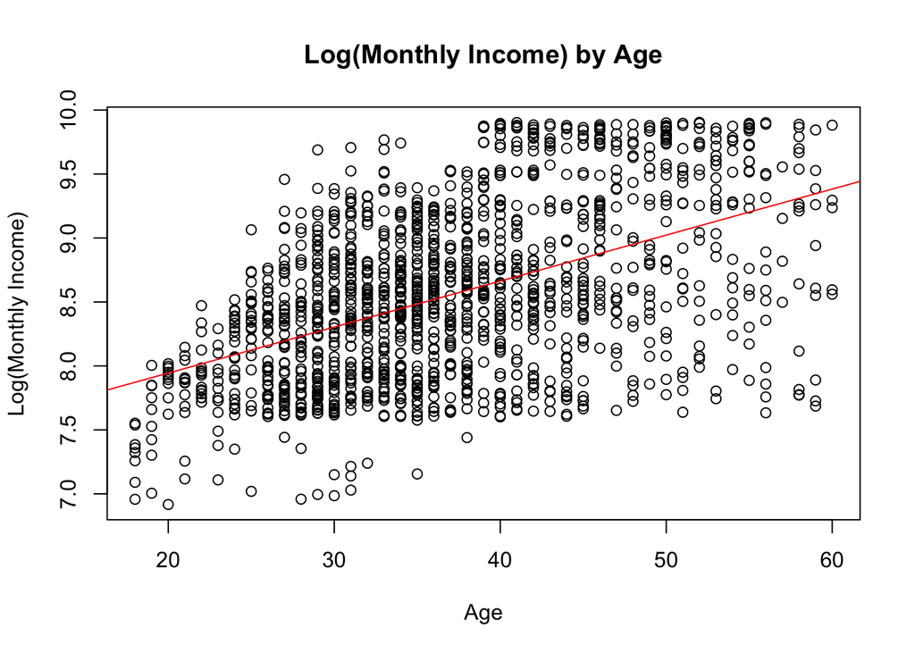

```r
Age.vs.Log.Mthly.Inc <- lm((log(data$MthlyInc))~data$Age)
plot(data$Age,log(data$MthlyInc),ylab='Log(Monthly Income)',xlab='Age',
     main='Log(Monthly Income) by Age')
abline(Age.vs.Log.Mthly.Inc,col='red')#log transform helps clarify the plots. There appears to be a relationship between age and monthly income, however age is really just a proxy for things like experience or time at a company/in the workforce. plotting those you get a much stronger relationship.
```

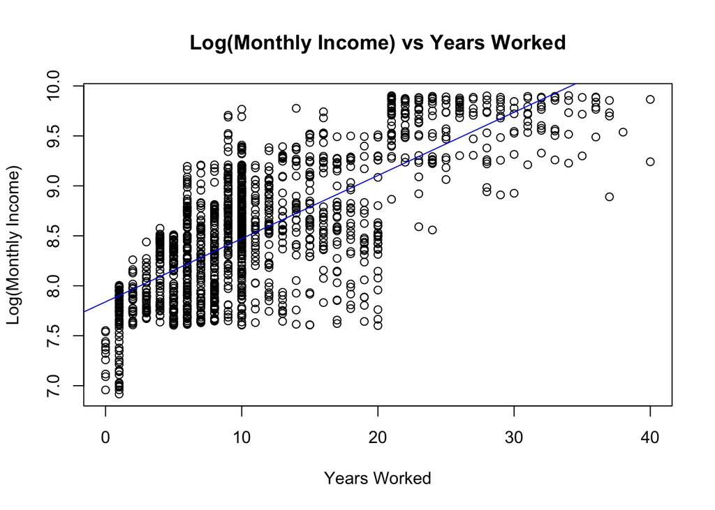

```r
plot(data$TotWrkYrs, log(data$MthlyInc),ylab='Log(Monthly Income)',xlab='Years Worked',main='Log(Monthly Income) vs Years Worked')
abline(lm((log(data$MthlyInc))~data$TotWrkYrs),col='blue')#You can see here that Years Worked has a similar trendline to Age.
```

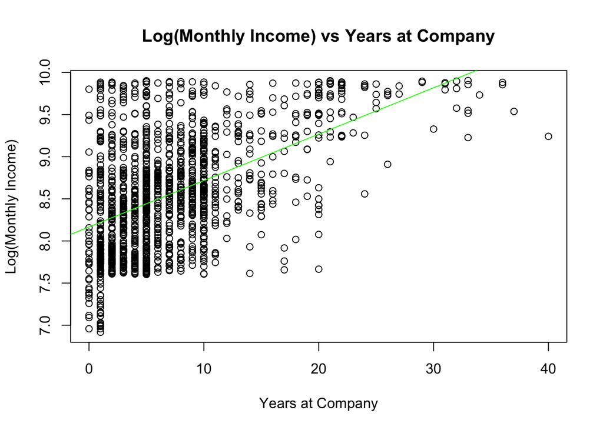

```r
plot(data$YrsAtComp, log(data$MthlyInc),ylab='Log(Monthly Income)',xlab='Years at Company',main='Log(Monthly Income) vs Years at Company')
abline(lm((log(data$MthlyInc))~data$YrsAtComp),col='green')#You can see again that Years at company and Years Worked are very similar in slope.
```

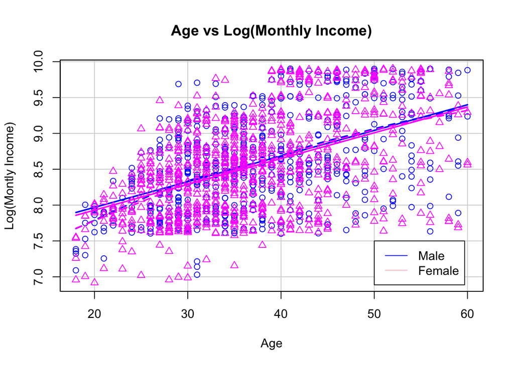

```r
scatterplot(log(data$MthlyInc)~data$Age | data$Gender,data=data,regLine=T,
            xlab='Age',ylab='Log(Montly Income)',main='Age vs Log(Monthly Income)',legend=F)
legend(50, 7.5, legend=c('Male','Female'),col=c('blue','pink'),lty=1:1,box.col='black')
```

```r
#It does not appear that either gender has a significant difference in the correlation between Age and the change in Monthly Income.
```

# Model Building time!!

```r
library(MASS)
library(tidyverse)
library(caret)
library(leaps)
head(data)
```

```
##   Age Attrition         BusTravel DailyRate             Department
## 1  41         1     Travel_Rarely      1102                  Sales
## 2  49         0 Travel_Frequently       279 Research & Development
## 3  37         1     Travel_Rarely      1373 Research & Development
## 4  33         0 Travel_Frequently      1392 Research & Development
## 5  27         0     Travel_Rarely       591 Research & Development
## 6  32         0 Travel_Frequently      1005 Research & Development
##   HomeDist Education     EducField EnviroSat Gender HourlyRate JobInvolv
## 1        1         2 Life Sciences         2 Female         94         3
## 2        8         1 Life Sciences         3   Male         61         2
## 3        2         2         Other         4   Male         92         2
## 4        3         4 Life Sciences         4 Female         56         3
## 5        2         1       Medical         1   Male         40         3
## 6        2         2 Life Sciences         4   Male         79         3
##   JobLevel            JobRole JobSat MaritalStat MthlyInc MonthlyRate
```

[output cut: 27 more lines]

```r
full.model <- lm(data$Attrition~.,data=data)
step.model <- stepAIC(full.model,direction = 'both')
```

```
## Start:  AIC=-3289.11
## data$Attrition ~ Age + BusTravel + DailyRate + Department + HomeDist +
##     Education + EducField + EnviroSat + Gender + HourlyRate +
##     JobInvolv + JobLevel + JobRole + JobSat + MaritalStat + MthlyInc +
##     MonthlyRate + NumCompWrk + OverTime + PercSalInc + PerfRating +
##     RelationSat + StkOptLevel + TotWrkYrs + TrnTmsLstYr + WrkLifeBal +
##     YrsAtComp + YrsCurrRole + YrsLstProm + YrsCurrMgr + LifeSat
##
##
## Step:  AIC=-3289.11
## data$Attrition ~ Age + BusTravel + DailyRate + Department + HomeDist +
##     Education + EducField + EnviroSat + Gender + HourlyRate +
##     JobInvolv + JobLevel + JobRole + JobSat + MaritalStat + MthlyInc +
##     MonthlyRate + NumCompWrk + OverTime + PercSalInc + PerfRating +
##     RelationSat + StkOptLevel + TotWrkYrs + TrnTmsLstYr + WrkLifeBal +
##     YrsAtComp + YrsCurrRole + YrsLstProm + YrsCurrMgr
##
##               Df Sum of Sq    RSS     AIC
## - Department   2    0.1283 147.70 -3291.8
## - MthlyInc     1    0.0030 147.57 -3291.1
## - JobLevel     1    0.0030 147.57 -3291.1
## - Education    1    0.0042 147.57 -3291.1
## - MonthlyRate  1    0.0153 147.59 -3291.0
## - HourlyRate   1    0.0182 147.59 -3290.9
## - PerfRating   1    0.0256 147.60 -3290.9
## - PercSalInc   1    0.0364 147.61 -3290.7
## - DailyRate    1    0.1607 147.73 -3289.5
## - StkOptLevel  1    0.1615 147.73 -3289.5
## <none>                     147.57 -3289.1
## - TotWrkYrs    1    0.2462 147.82 -3288.7
## - YrsAtComp    1    0.3500 147.92 -3287.6
## - Gender       1    0.4201 147.99 -3286.9
## - TrnTmsLstYr  1    0.4297 148.00 -3286.8
## - YrsCurrRole  1    0.5845 148.16 -3285.3
## - YrsCurrMgr   1    0.5998 148.17 -3285.1
## - WrkLifeBal   1    0.7017 148.27 -3284.1
## - Age          1    0.7197 148.29 -3284.0
## - EducField    5    1.5962 149.17 -3283.3
## - RelationSat  1    0.8854 148.46 -3282.3
## - YrsLstProm   1    1.0399 148.61 -3280.8
```

[output cut: 395 more lines]

```
## - YrsCurrMgr   1    0.6056 148.73 -3301.6
## - WrkLifeBal   1    0.7182 148.84 -3300.5
## - Age          1    0.7202 148.84 -3300.5
## - EducField    5    1.5630 149.69 -3300.2
## - RelationSat  1    0.8509 148.97 -3299.2
## - YrsLstProm   1    1.1499 149.27 -3296.3
## - HomeDist     1    1.1671 149.29 -3296.1
## - NumCompWrk   1    2.0998 150.22 -3286.9
## - BusTravel    2    2.6515 150.77 -3283.5
## - JobSat       1    2.5263 150.65 -3282.8
## - JobInvolv    1    2.5357 150.66 -3282.7
## - JobRole      8    4.1653 152.29 -3280.9
## - EnviroSat    1    2.8511 150.97 -3279.6
## - MaritalStat  2    4.7382 152.86 -3263.3
## - OverTime     1   12.8366 160.96 -3185.4
```

```r
summary(step.model)
```

```
##
## Call:
## lm(formula = data$Attrition ~ Age + BusTravel + HomeDist + EducField +
##     EnviroSat + Gender + JobInvolv + JobRole + JobSat + MaritalStat +
##     NumCompWrk + OverTime + RelationSat + TotWrkYrs + TrnTmsLstYr +
##     WrkLifeBal + YrsAtComp + YrsCurrRole + YrsLstProm + YrsCurrMgr,
##     data = data)
##
## Residuals:
##      Min       1Q   Median       3Q      Max
## -0.55412 -0.20848 -0.08452  0.08184  1.16098
##
## Coefficients:
##                               Estimate Std. Error t value Pr(>|t|)
## (Intercept)                   0.768831   0.112259   6.849 1.10e-11 ***
## Age                          -0.003459   0.001309  -2.642 0.008324 **
## BusTravelTravel_Frequently    0.155522   0.032884   4.729 2.47e-06 ***
## BusTravelTravel_Rarely        0.067197   0.028380   2.368 0.018030 *
## HomeDist                      0.003500   0.001041   3.364 0.000789 ***
## EducFieldLife Sciences       -0.091920   0.076380  -1.203 0.229000
## EducFieldMarketing           -0.048583   0.081501  -0.596 0.551204
## EducFieldMedical             -0.104775   0.076641  -1.367 0.171814
## EducFieldOther               -0.110221   0.082899  -1.330 0.183868
## EducFieldTechnical Degree     0.004170   0.080277   0.052 0.958584
## EnviroSat                    -0.040739   0.007749  -5.257 1.68e-07 ***
## GenderMale                    0.035324   0.017323   2.039 0.041617 *
## JobInvolv                    -0.059013   0.011902  -4.958 7.96e-07 ***
## JobRoleHumanResources         0.104357   0.061726   1.691 0.091124 .
## JobRoleLabTech                0.138352   0.035793   3.865 0.000116 ***
## JobRoleManager                0.040760   0.046023   0.886 0.375964
## JobRoleManufacturingDirector  0.017206   0.039049   0.441 0.659557
## JobRoleResearch Scientist     0.039686   0.035116   1.130 0.258611
## JobRoleResearchDirector       0.005665   0.047147   0.120 0.904381
## JobRoleSalesExecutive         0.077852   0.035743   2.178 0.029563 *
## JobRoleSalesRep               0.229293   0.048480   4.730 2.47e-06 ***
## JobSat                       -0.037891   0.007657  -4.949 8.34e-07 ***
## MaritalStat1                 -0.116213   0.019680  -5.905 4.39e-09 ***
## MaritalStat2                 -0.136745   0.023445  -5.833 6.74e-09 ***
## NumCompWrk                    0.017064   0.003782   4.512 6.95e-06 ***
## OverTime1                     0.210786   0.018895  11.156  < 2e-16 ***
## RelationSat                  -0.022509   0.007837  -2.872 0.004138 **
## TotWrkYrs                    -0.003839   0.002141  -1.793 0.073191 .
## TrnTmsLstYr                  -0.013695   0.006609  -2.072 0.038435 *
## WrkLifeBal                   -0.031665   0.012000  -2.639 0.008411 **
## YrsAtComp                     0.005450   0.002951   1.847 0.064982 .
## YrsCurrRole                  -0.009275   0.003844  -2.413 0.015956 *
## YrsLstProm                    0.011296   0.003383   3.339 0.000863 ***
## YrsCurrMgr                   -0.009555   0.003943  -2.423 0.015511 *
## ---
## Signif. codes:  0 '***' 0.001 '**' 0.01 '*' 0.05 '.' 0.1 ' ' 1
##
## Residual standard error: 0.3212 on 1436 degrees of freedom
## Multiple R-squared:  0.2549, Adjusted R-squared:  0.2378
## F-statistic: 14.88 on 33 and 1436 DF,  p-value: < 2.2e-16
```

```r
models <- regsubsets(Attrition~.,data=data,nvmax=3,method='seqrep')
summary(models)
```

```
## Subset selection object
## Call: regsubsets.formula(Attrition ~ ., data = data, nvmax = 3, method = "seqrep")
## 45 Variables  (and intercept)
##                                  Forced in Forced out
## Age                                  FALSE      FALSE
## BusTravelTravel_Frequently           FALSE      FALSE
## BusTravelTravel_Rarely               FALSE      FALSE
## DailyRate                            FALSE      FALSE
## DepartmentResearch & Development     FALSE      FALSE
## DepartmentSales                      FALSE      FALSE
## HomeDist                             FALSE      FALSE
## Education                            FALSE      FALSE
## EducFieldLife Sciences               FALSE      FALSE
## EducFieldMarketing                   FALSE      FALSE
## EducFieldMedical                     FALSE      FALSE
## EducFieldOther                       FALSE      FALSE
## EducFieldTechnical Degree            FALSE      FALSE
## EnviroSat                            FALSE      FALSE
## GenderMale                           FALSE      FALSE
## HourlyRate                           FALSE      FALSE
## JobInvolv                            FALSE      FALSE
## JobLevel                             FALSE      FALSE
## JobRoleHumanResources                FALSE      FALSE
## JobRoleLabTech                       FALSE      FALSE
## JobRoleManager                       FALSE      FALSE
## JobRoleManufacturingDirector         FALSE      FALSE
## JobRoleResearch Scientist            FALSE      FALSE
## JobRoleResearchDirector              FALSE      FALSE
## JobRoleSalesExecutive                FALSE      FALSE
## JobRoleSalesRep                      FALSE      FALSE
## JobSat                               FALSE      FALSE
## MaritalStat1                         FALSE      FALSE
## MaritalStat2                         FALSE      FALSE
## MthlyInc                             FALSE      FALSE
## MonthlyRate                          FALSE      FALSE
## NumCompWrk                           FALSE      FALSE
## OverTime1                            FALSE      FALSE
## PercSalInc                           FALSE      FALSE
## PerfRating                           FALSE      FALSE
## RelationSat                          FALSE      FALSE
```

[output cut: 44 more lines]

```
## 1  ( 1 ) " "    " "          " "          " "      " "         " "
## 2  ( 1 ) " "    " "          " "          " "      " "         " "
## 3  ( 1 ) " "    " "          " "          " "      " "         " "
##          OverTime1 PercSalInc PerfRating RelationSat StkOptLevel TotWrkYrs
## 1  ( 1 ) "*"       " "        " "        " "         " "         " "
## 2  ( 1 ) "*"       " "        " "        " "         " "         "*"
## 3  ( 1 ) "*"       " "        " "        " "         " "         "*"
##          TrnTmsLstYr WrkLifeBal YrsAtComp YrsCurrRole YrsLstProm
## 1  ( 1 ) " "         " "        " "       " "         " "
## 2  ( 1 ) " "         " "        " "       " "         " "
## 3  ( 1 ) " "         " "        " "       " "         " "
##          YrsCurrMgr LifeSat
## 1  ( 1 ) " "        " "
## 2  ( 1 ) " "        " "
## 3  ( 1 ) " "        "*"
```

```r
three.variable.model <- lm(Attrition~LifeSat+TotWrkYrs+OverTime,data=data)
summary(three.variable.model)  #Here is the summary of our 3 variables that contribute most to attrition, all very statistically significant
```

```
##
## Call:
## lm(formula = Attrition ~ LifeSat + TotWrkYrs + OverTime, data = data)
##
## Residuals:
##      Min       1Q   Median       3Q      Max
## -0.47867 -0.19059 -0.10836 -0.00939  1.26229
##
## Coefficients:
##              Estimate Std. Error t value Pr(>|t|)
## (Intercept)  0.462011   0.042214  10.944  < 2e-16 ***
## LifeSat     -0.032884   0.004801  -6.849 1.09e-11 ***
## TotWrkYrs   -0.008242   0.001159  -7.112 1.79e-12 ***
## OverTime1    0.214135   0.020082  10.663  < 2e-16 ***
## ---
## Signif. codes:  0 '***' 0.001 '**' 0.01 '*' 0.05 '.' 0.1 ' ' 1
##
## Residual standard error: 0.3456 on 1466 degrees of freedom
## Multiple R-squared:  0.1191, Adjusted R-squared:  0.1173
## F-statistic: 66.08 on 3 and 1466 DF,  p-value: < 2.2e-16
```

```r
set.seed(123)
train.control<-trainControl(method='cv',number=10)
step.model<- train(Attrition~.,data=data,method='leapSeq',
                   tuneGrid=data.frame(nvmax=1:5),
                   trControl=train.control)
```

[output not shown]

```r
step.model$results
```

```
##   nvmax      RMSE   Rsquared       MAE     RMSESD RsquaredSD      MAESD
## 1     1 0.3565093 0.06684005 0.2544113 0.02144852 0.05384809 0.01903455
## 2     2 0.3553919 0.06868547 0.2539091 0.02255957 0.03427621 0.01993211
## 3     3 0.3469839 0.11002717 0.2487952 0.02131980 0.04141560 0.01975767
## 4     4 0.3444390 0.12310870 0.2470204 0.02132118 0.05074924 0.01966790
## 5     5 0.3451454 0.12116753 0.2480955 0.02585776 0.06136194 0.02098461
```

```r
step.model$bestTune  #This tells us that our best model for predicting attrition has 4 variables.
```

```
##   nvmax
## 4     4
```

```r
summary(step.model$finalModel)
```

```
## Subset selection object
## 45 Variables  (and intercept)
##                                  Forced in Forced out
## Age                                  FALSE      FALSE
## BusTravelTravel_Frequently           FALSE      FALSE
## BusTravelTravel_Rarely               FALSE      FALSE
## DailyRate                            FALSE      FALSE
## DepartmentResearch & Development     FALSE      FALSE
## DepartmentSales                      FALSE      FALSE
## HomeDist                             FALSE      FALSE
## Education                            FALSE      FALSE
## EducFieldLife Sciences               FALSE      FALSE
## EducFieldMarketing                   FALSE      FALSE
## EducFieldMedical                     FALSE      FALSE
## EducFieldOther                       FALSE      FALSE
## EducFieldTechnical Degree            FALSE      FALSE
## EnviroSat                            FALSE      FALSE
## GenderMale                           FALSE      FALSE
## HourlyRate                           FALSE      FALSE
## JobInvolv                            FALSE      FALSE
## JobLevel                             FALSE      FALSE
## JobRoleHumanResources                FALSE      FALSE
## JobRoleLabTech                       FALSE      FALSE
## JobRoleManager                       FALSE      FALSE
## JobRoleManufacturingDirector         FALSE      FALSE
## JobRoleResearch Scientist            FALSE      FALSE
## JobRoleResearchDirector              FALSE      FALSE
## JobRoleSalesExecutive                FALSE      FALSE
## JobRoleSalesRep                      FALSE      FALSE
## JobSat                               FALSE      FALSE
## MaritalStat1                         FALSE      FALSE
## MaritalStat2                         FALSE      FALSE
## MthlyInc                             FALSE      FALSE
## MonthlyRate                          FALSE      FALSE
## NumCompWrk                           FALSE      FALSE
## OverTime1                            FALSE      FALSE
## PercSalInc                           FALSE      FALSE
## PerfRating                           FALSE      FALSE
## RelationSat                          FALSE      FALSE
## StkOptLevel                          FALSE      FALSE
```

[output cut: 55 more lines]

```
##          OverTime1 PercSalInc PerfRating RelationSat StkOptLevel TotWrkYrs
## 1  ( 1 ) "*"       " "        " "        " "         " "         " "
## 2  ( 1 ) "*"       " "        " "        " "         " "         "*"
## 3  ( 1 ) "*"       " "        " "        " "         " "         "*"
## 4  ( 1 ) "*"       " "        " "        " "         "*"         "*"
##          TrnTmsLstYr WrkLifeBal YrsAtComp YrsCurrRole YrsLstProm
## 1  ( 1 ) " "         " "        " "       " "         " "
## 2  ( 1 ) " "         " "        " "       " "         " "
## 3  ( 1 ) " "         " "        " "       " "         " "
## 4  ( 1 ) " "         " "        " "       " "         " "
##          YrsCurrMgr LifeSat
## 1  ( 1 ) " "        " "
## 2  ( 1 ) " "        " "
## 3  ( 1 ) " "        "*"
## 4  ( 1 ) " "        "*"
```

```r
best.tune.model <-lm(Attrition~data$OverTime+data$StkOptLevel+data$TotWrkYrs+LifeSat,data=data)
summary(best.tune.model)#Here is our new model after using 10fold cross-validation to estimate prediction error
```

```
##
## Call:
## lm(formula = Attrition ~ data$OverTime + data$StkOptLevel + data$TotWrkYrs +
##     LifeSat, data = data)
##
## Residuals:
##      Min       1Q   Median       3Q      Max
## -0.49463 -0.19661 -0.10609  0.01397  1.27461
##
## Coefficients:
##                   Estimate Std. Error t value Pr(>|t|)
## (Intercept)       0.512670   0.042701  12.006  < 2e-16 ***
## data$OverTime1    0.214240   0.019870  10.782  < 2e-16 ***
## data$StkOptLevel -0.059739   0.010473  -5.704 1.41e-08 ***
## data$TotWrkYrs   -0.008176   0.001147  -7.129 1.58e-12 ***
## LifeSat          -0.033375   0.004751  -7.025 3.27e-12 ***
## ---
## Signif. codes:  0 '***' 0.001 '**' 0.01 '*' 0.05 '.' 0.1 ' ' 1
##
## Residual standard error: 0.342 on 1465 degrees of freedom
## Multiple R-squared:  0.1383, Adjusted R-squared:  0.1359
## F-statistic: 58.76 on 4 and 1465 DF,  p-value: < 2.2e-16
```

### We have given our two best models, the best 3 variable model is

##### Attrition = 0.462-0.032*LifeSat-0.008*TotWrkYrs+0.214*OverTimeYes

### the best model however has 4 variables and is

##### Attrition = 0.513 + 0.214*OverTimeYes -0.06*StkOptLevel - 0.008*TotWrkYrs -0.0334*LifeSat

##### All of the coefficients have significant t-values, their absolute values are all greater than 5 which you can see in our summary report. These large t-statistics lead to very small probabilities that we would see this relationship between variables by chance.

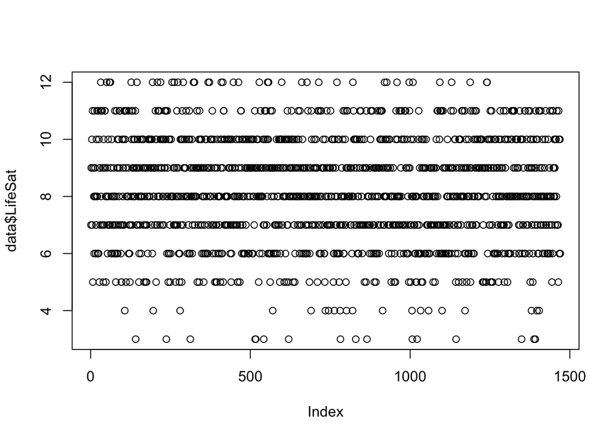

```r
plot(data$LifeSat)
```

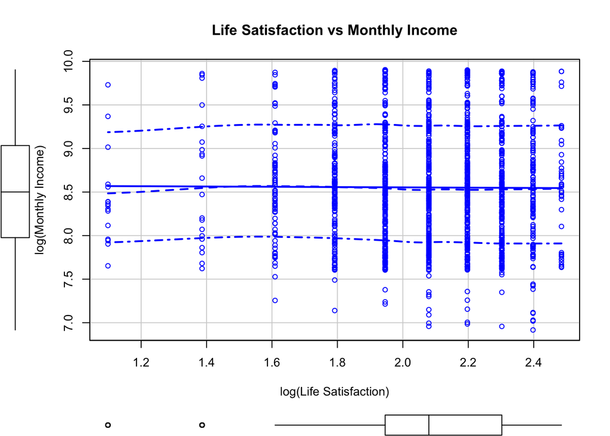

```r
scatterplot(log(data$MthlyInc)~log(data$LifeSat),data=data,regLine=T,
            xlab='log(Life Satisfaction)',ylab='log(Monthly Income)', main='Life Satisfaction vs Monthly Income')
```

```r
#there does not appear to be a clear relationship between Life Satisfaction and Monthly Income
```

## We cannot see a relationship between Life Satisfaction and Monthly Income, this relationship may be hidden within the groups of job roles and job levels and not life satisfaction.